# Tooth Growth data analysis

Aurimas R.

01/24/2015

# Tooth Growth dataset

Tooth growth dataset contains data from a trial where impact of vitamin C (administrated as orange juice or ascorbic acid) was tested on the lenght of guinea pig teeth. Three dose levels were applied. The dataset thus contains 60 observations with 3 variables: len (tooth length), supp (factor variable indicating delivery method) and dose (in miligrams). Let’s take a look at the data.

```r
summary(ToothGrowth$len)
```

```
##    Min. 1st Qu.  Median    Mean 3rd Qu.    Max.
##    4.20   13.08   19.25   18.81   25.28   33.90
```

```r
unique(ToothGrowth$dose)
```

```
## [1] 0.5 1.0 2.0
```

```r
unique(ToothGrowth$supp)
```

```
## [1] VC OJ
## Levels: OJ VC
```

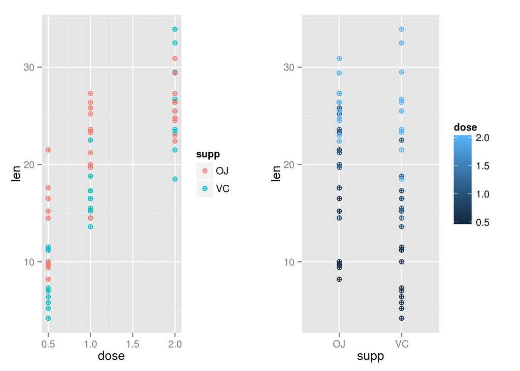

```r
p1 <- ggplot(data=ToothGrowth, aes(x=dose, y=len, colour=supp)) + geom_point(shape=10)
p2 <- ggplot(data=ToothGrowth, aes(x=supp, y=len, colour=dose)) + geom_point(shape=10)
multiplot(p1, p2, cols=2) #definition of multiplot function is in appendix.
```

It appears that there is a clear different in teeth length between the dosage groups - the higher the dose, the longer the teeth. The relationship between teeth length and delivery method is not that clear from visually inspecting the data. It appears, however, that VC (ascorbic acid) treatment group exhibited higher variance.

# Comparing tooth growth

## Impact of dosage levels

To compare the impact of dosage levels, let’s construct CI intervals (95%) of mean tooth length for each of the dosage levels. If the intervals do not intersect, we can state that the impact of dosage levels is indeed statistically significant with 95% confidence.

```r
func <- function(data, significance = 0.975) {
    mean <- mean(data)
    sd <- sd(data)
    mean + c(-1, 1) * qt(significance, length(data) - 1) * sd / sqrt(length(data))
}
tapply(ToothGrowth$len, ToothGrowth$dose, func)
```

```
## $`0.5`
## [1]  8.499046 12.710954
##
## $`1`
## [1] 17.66851 21.80149
##
## $`2`
## [1] 24.33364 27.86636
```

The confidence intervals clearly do not intersect, so the dosage levels have a significant impact to tooth length.

## Impact of treatment administration

To test if there is a significant relationship between teeth length and treatment administration, let’s consider testing if the means are the same using a T-test for uneven variances (see above - the variances look very different!). Note that the trial was performed only once on each guinea pig (poor pigs - they died in the name of science!), so we will use independent group comparison, not pair-wise comparison.

```r
t.test(len ~ supp, data=ToothGrowth, var.equal=FALSE, paired=FALSE)
```

```
##
##  Welch Two Sample t-test
##
## data:  len by supp
## t = 1.9153, df = 55.309, p-value = 0.06063
## alternative hypothesis: true difference in means is not equal to 0
## 95 percent confidence interval:
##  -0.1710156  7.5710156
## sample estimates:
## mean in group OJ mean in group VC
##         20.66333         16.96333
```

The output of the test indicates that the means appear to be not statistically different at 95% significance level. Thus, the delivery method did not have a statistically significant impact on teeth growth.

## Assumptions required

Note that besides the above stated assumptions (i.e. variances are unequal between treatment administration groups, the data is not paired), the above analysis only holds if:

- The means of the various subsets follow Student T distribution;
- There are no missing variables that are not taken into account; or, alternatively, the results do not consider that - i.e. there may not be any direct relationship between tooth length and treatment method directly, but treatment method may have an impact once dose level is considered
- The guinea pigs were selected randomly for the trial and assigned to the groups randomly, too